# Lecture #20

산점도의 최적 직선 찾기-회귀분석

Junho Ahn

2022-09-08

## lsfit 함수

### lsfit 함수의 사용법

**키와 몸무게 사이의 관계식 찾기**

- 이 관계식을 찾기 위해 100명의 키와 몸무게를 조사한 결과
- 첫 번째 사람의 키와 몸무게는 $(x_1, y_1)$, 두 번째 사람의 키와 몸무게는 $(x_2, y2)$, … ,100번째 사람의 키와 몸무게는 $(x_100, y_100)$으로 자료가 짝으로 얻어짐
- $i$번째 사람의 자료는 $(x_i, y_i)$로 표시
- $n$명을 조사한다면 $n$번째 자료는 $(x_n, y_n)$으로 표현

두 변수에 대한 자료 $(x_1, y_1), (x_2, y_2), ... ,(x_n, y_n)$가 있을 경우 이 자료들 사이의 관계를 직선의 방정식 $y=b_0 + b_1 x$로 표현하고자 $b_0, \; b_1$을 얻을 때 사용할 수 있는 함수로 `lsfit()`함수가 있음

### 두 변수 사이의 회귀식 사용

```r
BMI <- read.table("./bmi.txt",
                    col.names = c("height","weight","year","religion","gender","marriage"))
```

```r
lsfit(BMI$weight, BMI$height)
```

```
## $coefficients
##   Intercept           X
## 135.6921380   0.4938178
##
## $residuals
##   [1]  -2.2717478   2.1107902  -2.3830275   1.6540657  -1.3706631   0.6293369
##   [7]   1.6169725   1.1849767  -1.4201208  -5.8521165  -4.3582987  -3.9015742
##  [13]  -1.8644809  -4.9139386   3.0984258   0.6417013   3.6293369   5.5675148
##  [19]   1.1231547   0.7529810  -4.3582987 -10.3459343  -2.9015742   6.6293369
##  [25]  -0.7779300  -7.3212055  -0.3830275  -0.3582987   3.0984258   3.6169725
##  [31]   9.6540657   2.5922436   0.1726123   1.0984258  -1.3212055   5.6293369
##  [37]   1.6169725   2.6293369   0.1231547  -0.2593834   6.6293369   1.1355191
##  [43]  -0.4077564   0.6046080  -1.3953920  -0.8397521   0.1107902   1.5675148
##  [49]  -0.4077564   4.1602479  -5.8768453  -0.3830275  -4.2964766  -5.3582987
##  [55]   0.6046080   6.5922436   4.1478835   1.6169725  -2.8644809  -0.9139386
```

[output cut: 257 more lines]

회귀식 적용 1 : 몸무게 50(kg)인 경우 키(cm)예측

```r
135.6921380+50*0.4938178
```

```
## [1] 160.383
```

회귀식 적용 2: 몸무게 70(kg)인 경우 키(cm)예측

```r
135.6921380+70*0.4938178
```

```
## [1] 170.2594
```

회귀식 적용 3: 몸무게 60(kg)인 경우 키(cm)예측

```r
135.6921380+60*0.4938178
```

```
## [1] 165.3212
```

회귀식 적용 4: 여러 값에 대해서 한 번에 알고 싶은 경우

```r
reg.coef <- lsfit(BMI$weight, BMI$height)$coef
x <- seq(45, 80, by = 5)
y <- reg.coef[1] + reg.coef[2] * x
yhat <- data.frame(x,y)
yhat
```

| x | y |
| --- | --- |
| 45 | 157.9139 |
| 50 | 160.3830 |
| 55 | 162.8521 |
| 60 | 165.3212 |
| 65 | 167.7903 |
| 70 | 170.2594 |
| 75 | 172.7285 |
| 80 | 175.1976 |

## lm 함수

### lm 함수의 사용법

회귀분석에 사용할 수 있는 또 다른 함수로 `lm()`함수가 있음

### 일반적인 선형모형에 대한 식 사용

(BMI자료에서 키와 몸무게의 관계) lm함수를 사용하여 lsfit과 같은 결과를 얻는다.

```r
lm(height ~ weight, data = BMI)
```

```
##
## Call:
## lm(formula = height ~ weight, data = BMI)
##
## Coefficients:
## (Intercept)       weight
##    135.6921       0.4938
```

(산점도 회귀직선 그리기) 가상자료로 lm함수를 사용하여 산점도를 설명하는 직선의 식을 얻어보자.

```r
x <- seq(1,10)
y <- jitter(2*x+1)
lm(y ~ x)
```

```
##
## Call:
## lm(formula = y ~ x)
##
## Coefficients:
## (Intercept)            x
##       1.026        1.973
```

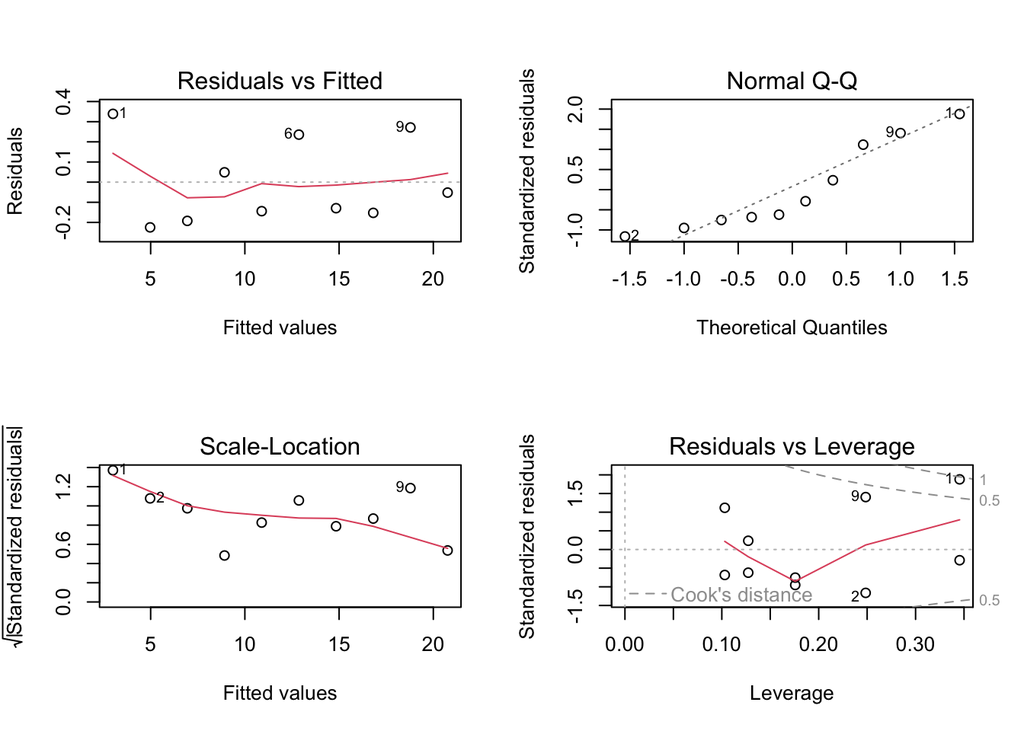

```r
par(mfrow = c(2,2))
plot(lm(y ~ x))
```

## plot 함수와 abline 함수

### abline 함수

$y$절편이 $a$이고 기울기가 $b$인 직선을 기존 그래프에 추가하는 함수

### plot과 abline에 대한 적용

(자료) 산점도에 겹쳐 그린 회귀직선 그림은 다음 두 명력의 결과이다.

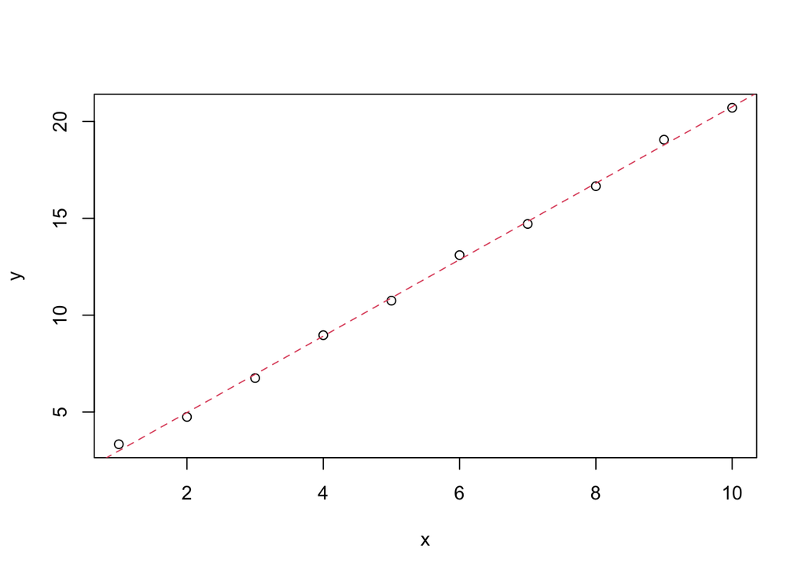

```r
plot(x,y)
abline(lm(y~x)$coef, lty=2, col=2)
```

(자료) abline함수로 직선을 추가하자.

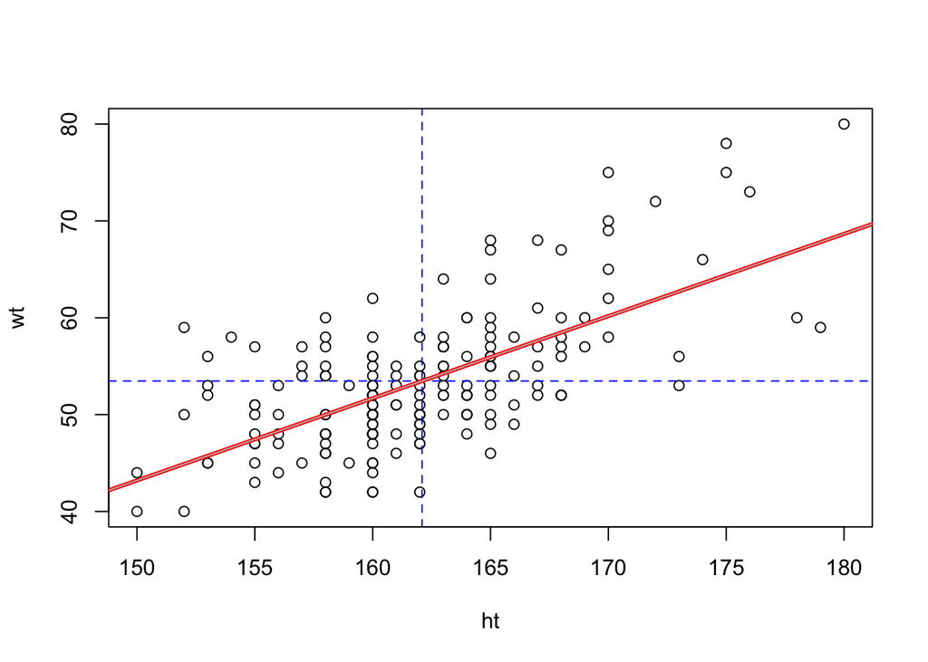

```r
ht <- BMI$height
wt <- BMI$weight
plot(ht, wt)
abline(v = mean(ht), lty = 2, col = "blue")
abline(h = mean(wt), lty = 2, col = "blue")
abline(lsfit(ht, wt), lw = 3, col = "red")
abline(lsfit(ht, wt)$coef, lw = 1, col = "gray")
```